# Feature Selection

Coreys Notes

# 1 Feature Selection

```r
library(dplyr)
library(TH.data)
library(caret)
data("GlaucomaM",package="TH.data")
mydf <- GlaucomaM
```

# 2 Boruta

Wrapper algorithm around random forest.

1. Adds randomness to a given data set by creating shuffled copies of all features (which are called shadow features).
2. Trains a random forest classifier on the extended data set and applies a feature importance measure (the default is mean decrease accuracy) to evaluate the importance of each feature where higher means more important.
3. At every iteration, it checks whether a real feature has a higher importance than the best of its shadow features. (whether the feature has a higher z scoret than the maximum z score of its shadow features) and consistently removes features that are deemed highly unimportant.
4. Algorithm stops when all features get confirmed or rejected or it reaches a specified limit of random forest runs.

```r
library(Boruta)
borutaoutput <- Boruta(Class~.,data=na.omit(mydf),doTrace=0)
borutaoutput
```

```
## Boruta performed 99 iterations in 7.757231 secs.
##  30 attributes confirmed important: abrg, abri, abrn, abrs, hic and 25
## more;
##  20 attributes confirmed unimportant: abrt, ai, an, at, eai and 15
## more;
##  12 tentative attributes left: ag, as, eag, ean, eas and 7 more;
```

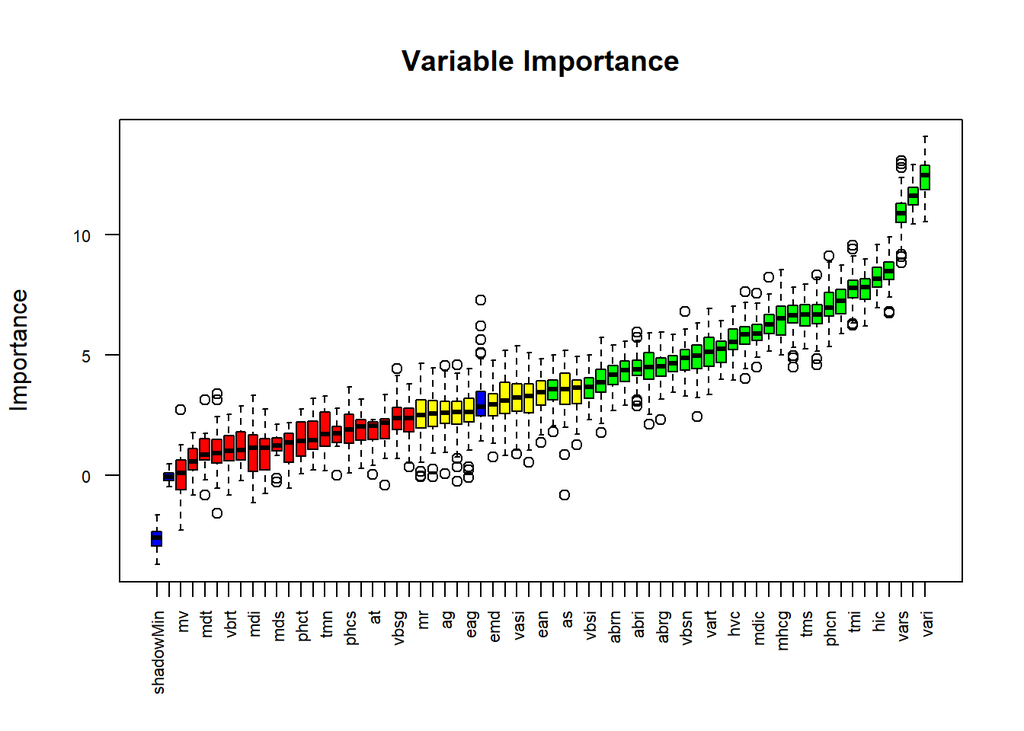

```r
plot(borutaoutput, cex.axis=.7, las=2, xlab="", main="Variable Importance")
```

```r
finalBoruta <- TentativeRoughFix(borutaoutput)
borutaDF <- attStats(finalBoruta)
borutaDF
```

```
##          meanImp  medianImp       minImp    maxImp   normHits  decision
## ag    2.58870107  2.6033740  0.067589074  4.562907 0.43434343  Rejected
## at    1.71512676  2.0579989  0.047411188  2.318530 0.00000000  Rejected
## as    3.53554927  3.5873124 -0.826164172  5.186602 0.65656566 Confirmed
## an    2.28894319  2.3878714  0.341238785  3.818340 0.16161616  Rejected
## ai    1.86500248  2.0178166  0.281888920  3.165612 0.04040404  Rejected
## eag   2.63744561  2.6390805 -0.087370589  4.437586 0.35353535  Rejected
## eat   1.67819822  1.7605162 -0.001734967  2.805272 0.00000000  Rejected
## eas   2.57609497  2.6355774 -0.234909672  4.600629 0.36363636  Rejected
## ean   3.38915274  3.4542202  1.363056693  4.842417 0.60606061  Rejected
## eai   1.93266790  2.1807809 -0.416418682  3.353932 0.03030303  Rejected
## abrg  4.48596150  4.5235443  2.317620834  5.947755 0.86868687 Confirmed
## abrt  1.67603056  1.4681172  0.243571684  3.198321 0.02020202  Rejected
## abrs  5.81112571  5.8632239  4.027241659  7.647233 0.96969697 Confirmed
## abrn  4.15753487  4.1862755  2.712046771  5.403177 0.78787879 Confirmed
## abri  4.41730470  4.4043310  2.884860418  5.958080 0.85858586 Confirmed
## hic   8.19858418  8.1762771  6.953854371  9.610092 1.00000000 Confirmed
## mhcg  6.48376580  6.5122943  5.021189766  8.556076 1.00000000 Confirmed
## mhct  0.52590642  0.5908375 -0.828488067  1.769695 0.00000000  Rejected
## mhcs  3.26267819  3.3039416  0.534225122  5.116421 0.57575758 Confirmed
## mhcn  4.49063715  4.5142361  2.114073438  5.938673 0.83838384 Confirmed
## mhci  7.25740244  7.2426419  5.881115504  8.751484 1.00000000 Confirmed
## phcg  6.69112112  6.6803564  4.590347873  8.344204 0.97979798 Confirmed
## phct  1.41873291  1.4459923  0.086118717  2.766094 0.02020202  Rejected
## phcs  1.95566836  1.9126491  0.093431093  3.669166 0.06060606  Rejected
## phcn  7.07095372  6.9745307  5.354853801  9.108902 1.00000000 Confirmed
## phci  8.52196606  8.4956936  6.759904473  9.898906 1.00000000 Confirmed
## hvc   5.60878499  5.5552919  3.977224984  7.018258 0.94949495 Confirmed
## vbsg  2.43626581  2.3787684  0.708754652  4.446715 0.11111111  Rejected
## vbst  1.08644832  0.9308096 -1.576969064  3.382543 0.01010101  Rejected
## vbss  3.44561197  3.6378599  1.285822000  4.946706 0.64646465  Rejected
## vbsn  4.81465751  4.8701719  3.296931574  6.801692 0.92929293 Confirmed
## vbsi  3.67467030  3.6702216  2.311015375  5.016273 0.71717172 Confirmed
## vasg  4.92643903  4.9771286  2.441728031  6.329359 0.90909091 Confirmed
## vast  0.99681661  1.1532684 -0.744147210  2.767257 0.01010101  Rejected
## vass  3.83291064  3.8672885  1.779360894  5.732321 0.74747475 Confirmed
## vasn  1.24622673  1.0500264 -0.211011685  2.886627 0.03030303  Rejected
## vasi  3.19753004  3.2388523  0.879584229  5.371010 0.57575758  Rejected
## vbrg  3.54546327  3.5688163  1.809449442  4.998009 0.70707071 Confirmed
## vbrt  1.01564692  1.0353591 -0.816189152  2.523304 0.01010101  Rejected
```

[output cut: 8 more lines]

```
## mdg   1.05698831  1.3569503 -0.541031583  2.184518 0.00000000  Rejected
## mdt   0.99271618  0.8491826 -0.826712913  3.142496 0.01010101  Rejected
## mds   1.13555341  1.2369321 -0.288040042  2.120019 0.00000000  Rejected
## mdn   2.53225679  2.5854572 -0.070151178  4.468567 0.34343434  Rejected
## mdi   1.04656881  1.1488356 -1.146251968  3.318251 0.03030303  Rejected
## tmg   6.30261888  6.2793920  5.177089971  8.249587 0.98989899 Confirmed
## tmt   3.12791826  3.0955596  0.828479276  5.197402 0.60606061 Confirmed
## tms   6.64255713  6.6782360  5.256091937  7.961162 0.98989899 Confirmed
## tmn   1.79585304  1.7170544  0.183802784  3.287736 0.03030303  Rejected
## tmi   7.72681133  7.7780479  6.254014822  9.573744 0.98989899 Confirmed
## mr    2.49512295  2.5056503 -0.051569551  4.662754 0.36363636  Rejected
## rnf   6.60932132  6.6664842  4.508524526  7.814488 0.98989899 Confirmed
## mdic  5.93083103  5.8968833  4.491804299  7.583689 0.97979798 Confirmed
## emd   2.92767319  2.9476979  0.768646649  4.775633 0.47474747 Confirmed
## mv    0.04817878  0.0970092 -2.264025457  2.744198 0.00000000  Rejected
```

```r
getConfirmedFormula(borutaoutput)
```

```
## Class ~ abrg + abrs + abrn + abri + hic + mhcg + mhcn + mhci +
##     phcg + phcn + phci + hvc + vbsn + vbsi + vasg + vass + vbrg +
##     vbrs + vbrn + vbri + varg + vart + vars + varn + vari + tmg +
##     tms + tmi + rnf + mdic
## <environment: 0x0000024615501528>
```

# 3 Random Forest

```r
rfmod <- train(Class~.,data=mydf,method="rf")
varImp(rfmod)$importance %>%
  as.data.frame()
```

```
##          Overall
## ag     7.7380396
## at     6.2083472
## as     7.3476746
## an     4.8483262
## ai    12.1851870
## eag   15.2994623
## eat    9.7198206
## eas   10.0743228
## ean   12.3271179
## eai   16.2058482
## abrg  23.3724379
## abrt   9.7612583
## abrs  28.9975544
## abrn  19.6353622
## abri  20.8281455
## hic   45.4933140
## mhcg  35.5910715
## mhct   6.2533985
## mhcs  22.0603201
## mhcn  24.3216465
## mhci  38.1955522
## phcg  48.3744796
## phct   6.7912306
## phcs  20.2016284
## phcn  41.0914774
## phci  45.5020642
## hvc   16.9184780
## vbsg  12.0011635
## vbst   0.0000000
## vbss  11.0668921
## vbsn  17.3995824
## vbsi  13.2005327
## vasg  12.4850598
## vast   0.4951770
## vass   7.6613459
## vasn   4.5847452
## vasi  12.7827451
## vbrg  26.1090847
## vbrt  11.1501096
```

[output cut: 8 more lines]

```
## mdg    4.2312193
## mdt    1.2158108
## mds    2.9970673
## mdn   14.6603872
## mdi    0.9715367
## tmg   37.5447241
## tmt   19.3883073
## tms   30.5367396
## tmn   12.3101729
## tmi   50.6647435
## mr    12.9233257
## rnf   55.9654527
## mdic  34.6981684
## emd   11.6984051
## mv     5.0951954
```

```r
rfmoddataframe <- varImp(rfmod)
rfmoddataframe
```

```
## rf variable importance
##
##   only 20 most important variables shown (out of 62)
##
##      Overall
## varg  100.00
## vari   71.85
## vars   70.32
## rnf    55.97
## varn   54.33
## tmi    50.66
## phcg   48.37
## phci   45.50
## hic    45.49
## phcn   41.09
## mhci   38.20
## tmg    37.54
## mhcg   35.59
## mdic   34.70
## vbri   32.45
## tms    30.54
## abrs   29.00
## vart   27.90
## vbrg   26.11
## vbrn   25.05
```

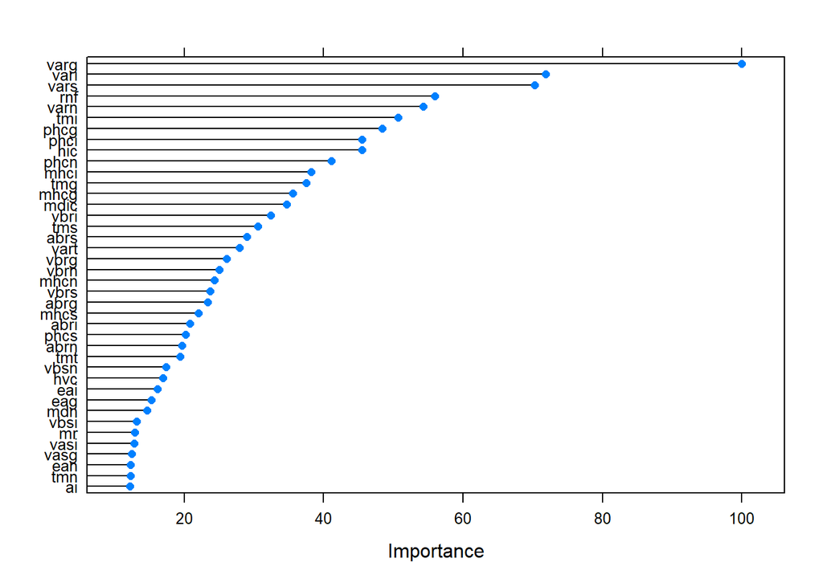

```r
plot(rfmoddataframe,top=40)
```

# 4 Recursive Feature Engineering

Trains on all variables, drops the least important predictor, then trains the model on p-1 predictors. Repeats until 1 predictor, chooses the subset of predictors that scored the best.

```r
# using recursive feature engineering
data(mpg)
head(mpg)
```

```
## # A tibble: 6 × 11
##   manufacturer model displ  year   cyl trans      drv     cty   hwy fl    class
##   <chr>        <chr> <dbl> <int> <int> <chr>      <chr> <int> <int> <chr> <chr>
## 1 audi         a4      1.8  1999     4 auto(l5)   f        18    29 p     compa…
## 2 audi         a4      1.8  1999     4 manual(m5) f        21    29 p     compa…
## 3 audi         a4      2    2008     4 manual(m6) f        20    31 p     compa…
## 4 audi         a4      2    2008     4 auto(av)   f        21    30 p     compa…
## 5 audi         a4      2.8  1999     6 auto(l5)   f        16    26 p     compa…
## 6 audi         a4      2.8  1999     6 manual(m5) f        18    26 p     compa…
```

```r
ctrl <- rfeControl(functions = rfFuncs,
                   method = "cv",
                   verbose = FALSE)
set.seed(12345)
rfe.train <- rfe(hwy~.,data=mpg,
                 sizes = 1:ncol(mpg)-1,
                 rfeControl = ctrl)

rfe.train$optVariables
```

```
##  [1] "cty"                         "displ"
##  [3] "drvf"                        "year"
##  [5] "cyl"                         "fle"
##  [7] "classsuv"                    "flp"
##  [9] "flr"                         "transauto(l4)"
## [11] "manufacturertoyota"          "drvr"
## [13] "classpickup"                 "fld"
## [15] "manufacturersubaru"          "classsubcompact"
## [17] "modelcaravan 2wd"            "classminivan"
## [19] "classmidsize"                "modelmustang"
## [21] "modelcorvette"               "manufacturerdodge"
## [23] "classcompact"                "transauto(l5)"
## [25] "modeltoyota tacoma 4wd"      "modelcorolla"
## [27] "modelcivic"                  "manufacturerhonda"
## [29] "modela4 quattro"             "modelram 1500 pickup 4wd"
```

[output cut: 23 more lines]

```r
varimp_data <- data.frame(feature = row.names(varImp(rfe.train))[1:20],
                          importance = varImp(rfe.train)[1:20, 1])
varimp_data
```

```
##               feature importance
## 1                 cty  32.515771
## 2               displ  19.429936
## 3                drvf  15.415593
## 4                year  14.414224
## 5                 cyl  13.185758
## 6                 fle  11.133568
## 7            classsuv  10.268266
## 8                 flp   9.928421
## 9                 flr   9.460566
## 10 manufacturertoyota   8.485999
## 11      transauto(l4)   8.462989
## 12        classpickup   8.410197
## 13               drvr   8.016055
## 14    classsubcompact   7.717629
## 15                fld   7.647546
## 16 manufacturersubaru   7.622312
## 17   modelcaravan 2wd   7.607306
## 18       classminivan   7.478362
## 19       classmidsize   7.239364
## 20       modelmustang   6.985886
```

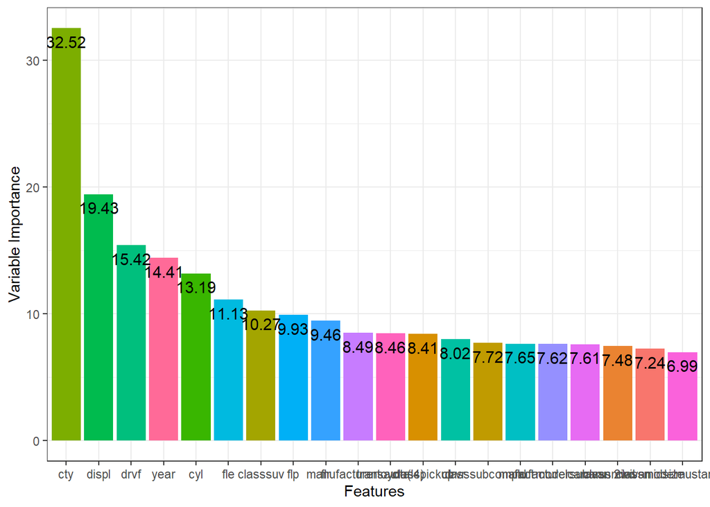

```r
ggplot(data = varimp_data,
       aes(x = reorder(feature, -importance), y = importance, fill = feature)) +
  geom_bar(stat="identity") + labs(x = "Features", y = "Variable Importance") +
  geom_text(aes(label = round(importance, 2)), vjust=1.6, color="black", size=4) +
  theme_bw() + theme(legend.position = "none")
```

# 5 Genetic Algorithms

1. Creates a random binary string.
2. Assigns a fitness score to each individual

```r
# Define control function
ga_ctrl <- gafsControl(functions = rfGA,  # another option is `caretGA`.
                       method = "cv",
                       number=3)

dependent <- mydf[,1]
predictors <- mydf[,2:8]

ga_obj <- gafs(x=predictors,y=dependent,
               iters = 5,   # normally much higher (100+)
               gafsControl = ga_ctrl,
               method="lm")
ga_obj2 <- gafs(x=predictors,y=dependent,
               iters = 5,   # normally much higher (100+)
               gafsControl = ga_ctrl)


ga_obj
```

```
##
## Genetic Algorithm Feature Selection
##
## 196 samples
## 7 predictors
##
## Maximum generations: 5
## Population per generation: 50
## Crossover probability: 0.8
## Mutation probability: 0.1
## Elitism: 0
##
## Internal performance values: RMSE, Rsquared
## Subset selection driven to minimize internal RMSE
##
## External performance values: RMSE, Rsquared, MAE
## Best iteration chose by minimizing external RMSE
## External resampling method: Cross-Validated (3 fold)
##
## During resampling:
##   * the top 4 selected variables (out of a possible 7):
##     ai (100%), an (100%), as (100%), at (100%)
##   * on average, 4 variables were selected (min = 4, max = 4)
##
## In the final search using the entire training set:
##    * 4 features selected at iteration 5 including:
##      at, as, an, ai
##    * external performance at this iteration is
##
##         RMSE     Rsquared          MAE
##      0.06791      0.98852      0.02539
```

```r
ga_obj2
```

```
##
## Genetic Algorithm Feature Selection
##
## 196 samples
## 7 predictors
##
## Maximum generations: 5
## Population per generation: 50
## Crossover probability: 0.8
## Mutation probability: 0.1
## Elitism: 0
##
## Internal performance values: RMSE, Rsquared
## Subset selection driven to minimize internal RMSE
##
## External performance values: RMSE, Rsquared, MAE
## Best iteration chose by minimizing external RMSE
## External resampling method: Cross-Validated (3 fold)
##
## During resampling:
##   * the top 4 selected variables (out of a possible 7):
##     ai (100%), an (100%), as (100%), at (100%)
##   * on average, 4 variables were selected (min = 4, max = 4)
##
## In the final search using the entire training set:
##    * 4 features selected at iteration 5 including:
##      at, as, an, ai
##    * external performance at this iteration is
##
##         RMSE     Rsquared          MAE
##      0.07147      0.98754      0.02834
```

```r
ga_obj$optVariables
```

```
## [1] "at" "as" "an" "ai"
```

```r
ga_obj2$fit
```

```
##
## Call:
##  randomForest(x = x, y = y)
##                Type of random forest: regression
##                      Number of trees: 500
## No. of variables tried at each split: 1
##
##           Mean of squared residuals: 0.006620445
##                     % Var explained: 98.47
```

# 6 Information Gain

```r
# information value
library(FSelector)

# get information gain results
?information.gain
```

```
## starting httpd help server ... done
```

```r
infoGain <- information.gain(as~.,data=mydf) %>%
  as.data.frame() %>%
  arrange(desc(attr_importance))
infoGain
```

```
##       attr_importance
## ai         1.28362123
## ag         1.25534495
## mr         1.25534495
## an         0.99411872
## at         0.82251781
## eas        0.66341533
## eat        0.60512800
## eag        0.54326094
## eai        0.49462096
## abrt       0.44570155
## abrs       0.36619235
## vbss       0.32139963
## vbsg       0.30439831
## ean        0.27950184
## vbsn       0.25382732
## abrg       0.20835912
## vbst       0.19774579
## vbrs       0.18124064
## vbsi       0.17339103
## abrn       0.16190451
## vbrg       0.16158156
## abri       0.15763537
## vbrt       0.15544510
## vbrn       0.14676970
## vbri       0.14087645
## tms        0.11174445
## mdic       0.10622242
## mdn        0.10541869
## emd        0.10140823
## tmn        0.09149728
## tmg        0.08163739
## Class      0.01936742
## hic        0.00000000
## mhcg       0.00000000
## mhct       0.00000000
## mhcs       0.00000000
## mhcn       0.00000000
## mhci       0.00000000
## phcg       0.00000000
```

[output cut: 8 more lines]

```
## vasn       0.00000000
## vasi       0.00000000
## varg       0.00000000
## vart       0.00000000
## vars       0.00000000
## varn       0.00000000
## vari       0.00000000
## mdg        0.00000000
## mdt        0.00000000
## mds        0.00000000
## mdi        0.00000000
## tmt        0.00000000
## tmi        0.00000000
## rnf        0.00000000
## mv         0.00000000
```

# 7 Filter Methods

For scores less than .05 statistically significant.

For binary dependent variable:

```r
pScore <- function(x,y){
  numX <- length(unique(x))
  if(numX>2){
    out <- t.test(x~y)$p.value
  }else{
    #binary predictor
    out <- fisher.test(factor(x),y)$p.value
  }
  out
}

mydf$dependent <- rep(c(0,1),98)
scores <- apply(X=mydf[,2:10],
                MARGIN = 2,
                FUN=pScore,
                y=mydf$dependent)

scoresDF <- as.data.frame(scores)
scoresDF %>%
  arrange(scores)
```

```
##        scores
## at  0.3707925
## an  0.5001558
## ean 0.7072909
## as  0.8143195
## ai  0.8531434
## eai 0.8607188
## eag 0.8869471
## eas 0.9057457
## eat 0.9734090
```